# Předmět: MPE _BAAN Bayesiánska analýza

První úkol

Dana Kozáková

2026-07-14

# Exercise 2.4: Vampires?

*Zdroj: [Exercise 2.4](https://www.bayesrulesbook.com/chapter-2#exercises-1)*

> Edward sa snaží dokázať Belle, že upíri existujú. Bella si myslí, že existuje pravdepodobnosť 0.05, že upíri existujú. Tiež verí, že pravdepodobnosť, že niekto môže žiariť ako diamant za predpokladu, že upíri existujú, je 0.7, a pravdepodobnosť, že niekto môže žiariť ako diamant za predpokladu, že upíri neexistujú, je 0.03.

> **Otázka:** Vzhľadom na to, že Edward zažiaril ako diamant, aká je pravdepodobnosť, že upíri existujú?

## Solution

### Definícia udalostí

- $V$ = udalosť “upíri existujú”
- $V^c$ = udalosť “upíri neexistujú” (komplement)
- $S$ = udalosť “žiariť ako diamant” (sparkle)

Pravdepodobnosť existencie upírov:
$$\begin{equation}
P(V) = 0.05
\end{equation}$$

Pravdepodobnosť, že niekto žiari ako diamant, ak upíri existujú:
$$\begin{equation}
P(S|V) = 0.7
\end{equation}$$

Pravdepodobnosť, že niekto žiari ako diamant, ak upíri neexistujú:
$$\begin{equation}
P(S|V^c) = 0.03
\end{equation}$$

### Hľadáme

P(ak Edward žiari, aká je pravdepodobnosť, že upíri existujú?)
$$\begin{equation}
P(V|S) = \; ?
\end{equation}$$

### Z Bayesovo vzorca

$$\begin{equation}
P(V|S) = \frac{P(V) \cdot P(S|V)}{P(S)}
\end{equation}$$

Nepoznáme P(S) = pravdepodobnosť, že niekto žiari → vypočítame cez vzťah úplnej pravdepodobnosti:
$$\begin{align}
P(S) &= P(S|V) \cdot P(V) + P(S|V^c) \cdot P(V^c) \\
&= 0.7 \times 0.05 + 0.03 \times 0.95 \\
&= 0.035 + 0.0285 \\
&= 0.0635
\end{align}$$

Celková pravdepodobnosť, že niekto žiari ako diamant je **6,35%**. Môžeme dosadiť do Bayesovho vzorca:
$$\begin{align}
P(V|S) &= \frac{P(V) \cdot P(S|V)}{P(S)} = \frac{0.05 \times
0.7}{0.0635} = \frac{0.7}{12.7} \\
&= \frac{70}{127} \approx 0.5512
\end{align}$$

**Odpoveď:** Keď Edward zažiaril ako diamant, pravdepodobnosť, že upíri existujú, je približne **55%** (alebo presne $\frac{70}{127}$).

# Exercise 2.11: Muhammad’s Internship Applications

*Zdroj: [Exercise 2.11](https://www.bayesrulesbook.com/chapter-2#exercises-1)*

> Muhammad sa hlási na šesť rovnako kompetitívnych stáží (internships) v oblasti data science. Má nasledujúci apriórny model pre svoje šance na prijatie na akúkoľvek z daných stáží, $\pi$:

|  | π 0.3 | π 0.4 | π 0.5 | π Total |
| --- | --- | --- | --- | --- |
| f(π) | 0.25 | 0.6 | 0.15 | 1 |

> 1. Nech $Y$ je počet ponúk na stáž, ktoré Muhammad dostane. Špecifikujte model pre závislosť $Y$ od $\pi$ a zodpovedajúcu pravdepodobnostnú funkciu (pmf), $f(y|\pi)$.
> 2. Muhammad dostal celkom úžasné správy. Ponúkli mu štyri zo šiestich stáží! Aké pravdepodobné by to bolo, keby $\pi = 0.3$?
> 3. Zostrojte posteriórny model pre $\pi$ vo svetle Muhammadových správ o stážach.

## Solution

### a. Model závislosti $Y$ na $\pi$

Muhammad sa uchádzal o $n = 6$ stáží. Predpokladáme, že:

- Každá stáž má rovnakú pravdepodobnosť prijatia $\pi$
- Prijatia sú navzájom nezávislé

Preto počet prijatých stáží $Y$ má **binomické rozdelenie**:

> $$\begin{equation}
> Y | \pi \sim \text{Bi}(n = 6, p = \pi)
> \end{equation}$$

Pravdepodobnostná funkcia (pmf) pre binomické rozdelenie je:

> $$\begin{equation}
> f(y|\pi) = \binom{6}{y} \pi^y (1-\pi)^{6-y} \quad \text{pre } y \in \{0,
> 1, 2, 3, 4, 5, 6\}
> \end{equation}$$
> kde $\binom{6}{y} = \frac{6!}{y!(6-y)!}$ je binomický koeficient, ktorý nezávisí od hyperparametra, len od dát.

### b. Likelihood funkcia

Muhammad dostal **4 ponuky z 6** stáží, teda $y = 4$. Vierohodnostná funkcia má rovnaký tvar ako pmf, len iné chápanie parametra:

> $$\begin{equation}
> L(\pi|y = 4) = f(y = 4|\pi) = \binom{6}{4} \pi^4 (1-\pi)^{6-4}
> \end{equation}$$

Pre $\pi = 0.3$ vypočítame likelihood:

```r
# Výpočet vierohodnosti pre π = 0.3
n <- 6
y <- 4
pi_03 <- 0.3

likelihood_03 <- dbinom(y, size = n, prob = pi_03)
cat('Vierohodnosť pre hodnotu pi 0.3 je: ', likelihood_03)
```

```
## Vierohodnosť pre hodnotu pi 0.3 je:  0.059535
```

**Interpretácia:** Ak by pravdepodobnosť prijatia bola len $\pi = 0.3$, potom by bolo dosť nepravdepodobné (približne 6%), že Muhammad dostane 4 z 6 ponúk.

### c. Posteriórny model

#### 1. Apriórny model

Náš prior model pre $\pi$ je:

```r
# Apriórny model
prior_data <- data.frame(
  pi = c(0.3, 0.4, 0.5),
  f_pi = c(0.25, 0.60, 0.15)
)

kable(prior_data,
      col.names = c("π", "f(π)"),
      caption = "Apriórny model",
      align = 'c') %>%
  kable_styling(full_width = FALSE)
```

Apriórny model

| π | f(π) |
| --- | --- |
| 0.3 | 0.25 |
| 0.4 | 0.60 |
| 0.5 | 0.15 |

#### 2. Výpočet Likelihood funkcie

Pre pozorovanie $y = 4$ vypočítame likelihood pre každé možné $\pi$:

$$L(\pi | y = 4) = f(y = 4 | \pi) =
\binom{6}{4} \pi^4 (1-\pi)^2 = 15 \pi^4 (1-\pi)^2$$

```r
# Výpočet likelihood pre všetky π
likelihood_data <- prior_data %>%
  mutate(
    L_pi = dbinom(y, size = n, prob = pi)
  )

kable(likelihood_data,
      col.names = c("π", "f(π)", "L(π/y=4)"),
      caption = "Apriórny model a Likelihood funkcia",
      align = 'c',
      digits = 6) %>%
  kable_styling(full_width = FALSE)
```

Apriórny model a Likelihood funkcia

| π | f(π) | L(π/y=4) |
| --- | --- | --- |
| 0.3 | 0.25 | 0.059535 |
| 0.4 | 0.60 | 0.138240 |
| 0.5 | 0.15 | 0.234375 |

**Interpretácia likelihood:** Dáta (y=4) sú **najviac kompatibilné** s $\pi = 0.5$ (tu je najvyššia vierohodnosť) a **najmenej kompatibilné** s $\pi = 0.3$. Vidno to aj na grafoch - viď výška stĺpca pre hodnotu 4:

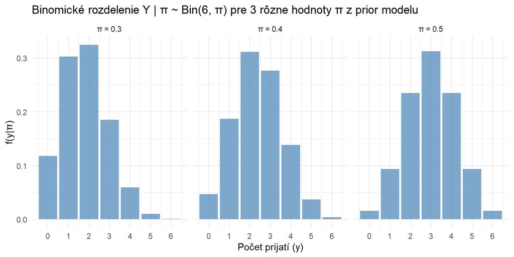

#### 3. Posteriórny model

Bayesovo pravidlo hovorí:

$$f(\pi | y) = \frac{f(\pi) \cdot
L(\pi|y)}{f(y)} \propto f(\pi) \cdot L(\pi|y)$$

**Krok 1:** Súčin prior × likelihood (nenormalizovaný posterior)

```r
# Nenormalizovaný posterior
posterior_data <- likelihood_data %>%
  mutate(
    prior_times_likelihood = f_pi * L_pi
  )

kable(posterior_data,
      col.names = c("π", "f(π)", "L(π/y=4)", "f(π) × L(π/y=4)"),
      caption = "Výpočet nenormalizovaného posterioru",
      align = 'c',
      digits = 6) %>%
  kable_styling(full_width = FALSE)
```

Výpočet nenormalizovaného posterioru

| π | f(π) | L(π/y=4) | f(π) × L(π/y=4) |
| --- | --- | --- | --- |
| 0.3 | 0.25 | 0.059535 | 0.014884 |
| 0.4 | 0.60 | 0.138240 | 0.082944 |
| 0.5 | 0.15 | 0.234375 | 0.035156 |

**Krok 2:** Normalizačná konštanta, aby súčet bol 1
$$f(\pi | y = 4) = \frac{f(\pi) \cdot
L(\pi|y=4)}{\sum_{\text{všetky } \pi} f(\pi) \cdot
L(\pi|y=4)}$$

```r
# Suma pre normalizáciu
sum_prior_likelihood <- sum(posterior_data$prior_times_likelihood)
cat(sprintf("\nNormalizačná konštanta f(y=4) = %.6f\n", sum_prior_likelihood))
```

```
##
## Normalizačná konštanta f(y=4) = 0.132984
```

**Krok 3:** Normalizovaný posterior

```r
# Normalizovaný posterior
posterior_data <- posterior_data %>%
  mutate(
    f_pi_given_y = prior_times_likelihood / sum_prior_likelihood
  )

# Finálna tabuľka
final_table <- posterior_data %>%
  select(pi, f_pi, L_pi, f_pi_given_y)

kable(final_table,
      col.names = c("π", "Prior f(π)", "Likelihood L(π/y=4)", "Posterior f(π/y=4)"),
      caption = "Porovnanie: Prior → Likelihood → Posterior",
      align = 'c',
      digits = 6) %>%
  kable_styling(full_width = FALSE)
```

Porovnanie: Prior → Likelihood → Posterior

| π | Prior f(π) | Likelihood L(π/y=4) | Posterior f(π/y=4) |
| --- | --- | --- | --- |
| 0.3 | 0.25 | 0.059535 | 0.111921 |
| 0.4 | 0.60 | 0.138240 | 0.623714 |
| 0.5 | 0.15 | 0.234375 | 0.264365 |

Tu vidíme, že na základe výsledku sa zvýšila pravdepodobnosť pre $\pi$ 0.4 aj 0.5 a naopak poklesla pravdepodobnosť hodnoty 0.3. Dôvodom je, že jeho úspešnosť bola 4/6 = približne 0,66.

# Exercise 3.9: Interpreting Priors

*Zdroj: [Exercise 3.9](https://www.bayesrulesbook.com/chapter-3#exercises-2)*

> Ako nazývate sladký sýtený nápoj: pop, soda, coke, alebo inak? Nech $\pi$ je podiel obyvateľov USA, ktorí uprednostňujú výraz "pop". Dvaja rôzni predajcovia nápojov z rôznych regiónov krajiny majú pre $\pi$ rôzne priory. Prvý predajca pracuje v Severnej Dakote (North Dakota) a špecifikuje apriórny model Beta(8,2). Druhý pracuje v Louisiane a špecifikuje apriórny model Beta(1,20).
> 1. Vypočítajte apriórnu strednú hodnotu, modus a smerodajnú odchýlku pre $\pi$ pre oboch predajcov.
> 2. Vykreslite apriórne funkcie hustoty (pdf) pre oboch predajcov.
> 3. Slovne porovnajte apriórne chápanie predajcov ohľadom podielu obyvateľov USA, ktorí hovoria "pop".

## Solution

### a. Charakteristiky apriórnych modelov

**Parameter:** $\pi$ = podiel obyvateľov USA, ktorí používajú výraz “pop” pre sladené nápoje **Dvaja predajcovia z rôznych regiónov:**

1. **Predajca z North Dakota (ND):** má apriórny model $\pi \sim \text{Beta}(8, 2)$
2. **Predajca z Louisiana (LA):** má apriórny model $\pi \sim \text{Beta}(1, 20)$

#### Vzorce pre Beta rozdelenie

> Pre $\pi \sim \text{Beta}(\alpha, \beta)$ platí:
> $$\begin{align}
> E(\pi) &= \frac{\alpha}{\alpha + \beta} \\
> Mode(\pi) &= \frac{\alpha - 1}{\alpha + \beta - 2} \quad \text{pre }
> \alpha, \beta > 1 \\
> Var(\pi) &= \frac{\alpha \beta}{(\alpha + \beta)^2(\alpha + \beta +
> 1)} \\
> SD(\pi) &= \sqrt{\text{Var}(\pi)}
> \end{align}$$

#### Predajca z North Dakota: Beta(8, 2)

> $$\begin{align}
> E(\pi) &= \frac{8}{8 + 2} = \frac{8}{10} = 0.8 \\
> Mode(\pi) &= \frac{8 - 1}{8 + 2 - 2} = \frac{7}{8} = 0.875 \\
> Var(\pi) &= \frac{8 \times 2}{10^2 \times 11} = \frac{16}{1100}
> \approx 0.0145 \\
> SD(\pi) &= \sqrt{0.0145} \approx 0.1205
> \end{align}$$

#### Predajca z Louisiana: Beta(1, 20)

> $$\begin{align}
> E(\pi) &= \frac{1}{1 + 20} = \frac{1}{21} \approx 0.0476 \\
> Mode(\pi) &= \text{nedfinované, lebo } \alpha \text{ nie je > 1}
> \\
> Var(\pi) &= \frac{1 \times 20}{21^2 \times 22} = \frac{20}{9702}
> \approx 0.0021 \\
> SD(\pi) &= \sqrt{0.0021} \approx 0.0453
> \end{align}$$

#### Porovnanie charakteristík

```r
alpha_nd <- 8
beta_nd <- 2

alpha_la <- 1
beta_la <- 20

summarize_beta(alpha = alpha_nd, beta = beta_nd)
```

```
##   mean  mode        var        sd
## 1  0.8 0.875 0.01454545 0.1206045
```

```r
summarize_beta(alpha = alpha_la, beta = beta_la)
```

```
##         mean mode         var         sd
## 1 0.04761905    0 0.002061431 0.04540298
```

### b. Grafy apriórnych hustôt pravdepodobnosti (pdf)

#### Graf pre North Dakota

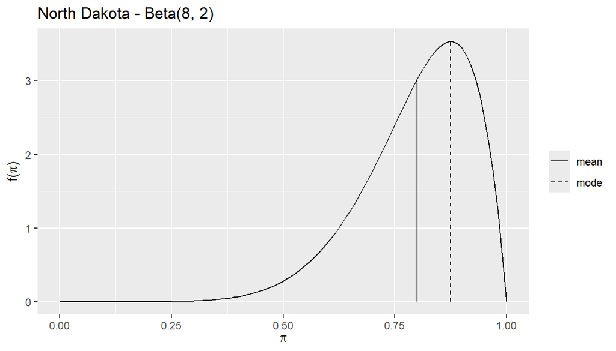

```r
plot_beta(alpha = alpha_nd, beta = beta_nd, mean = TRUE, mode = TRUE) +
  labs(title = "North Dakota - Beta(8, 2)")
```

#### Graf pre Louisiana

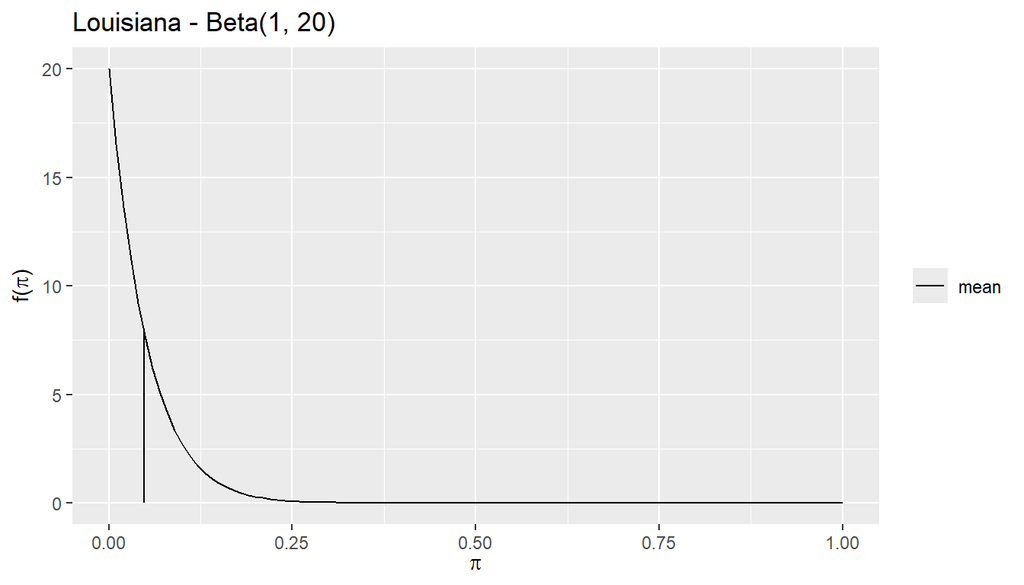

```r
plot_beta(alpha = alpha_la, beta = beta_la, mean = TRUE, mode = FALSE) +
  labs(title = "Louisiana - Beta(1, 20)")
```

### c. Porovnanie a interpretácia apriórnych modelov

#### Stredná hodnota, modus

**North Dakota - Beta(8, 2):**

- Stredná hodnota: $E(\pi) = 0.80$ (80%)
- Modus: $\text{Mode}(\pi) = 0.875$ (87.5%)
- Predajca z North Dakota verí, že väčšina (približne 80%) obyvateľov USA používa výraz “pop”

**Louisiana - Beta(1, 20):**

- Stredná hodnota: $E(\pi) = 0.048$ (4.8%)
- Distribúcia je klesajúca (maximum pri $\pi = 0$)
- Predajca z Louisiana verí, že len veľmi malá časť (približne 5%) obyvateľov USA používa výraz “pop”

Oba predajcovia majú **diametrálne odlišné** presvedčenia. North Dakota verí, že “pop” je veľmi populárne, zatiaľ čo Louisiana verí opak.

#### Variabilita (neistota)

**North Dakota - Beta(8, 2):**

- Smerodajná odchýlka: $\text{SD}(\pi) = 0.121$ (12.1%)

**Louisiana - Beta(1, 20):**

- Smerodajná odchýlka: $\text{SD}(\pi) = 0.045$ (4.5%)

Predajca z Louisiana je **istejší** vo svojom presvedčení (menšia SD) ako ten z NA, lebo SD pre neho je nižšia.

#### Parametre $\alpha$ a $\beta$

**North Dakota - Beta(8, 2):**

- súčet je 10: akoby videl, 8 - 1 = 7 ľudí, ktorí hovoria “pop” vs. 2 - 1 = 1, ktorý to slovo nepoužíva

**Louisiana - Beta(1, 20):**

- súčet je 21: akoby nepoznal žiadneho (1 - 1 = 0), ktorý hovorí “pop” vs. 20 - 1 = 19, ktorí to slovo nepoužívajú
- súčet je vyšší, teda si je viac istejší

# Exercise 3.11: Regular Bike Ridership

*Zdroj: [Exercise 3.11](https://www.bayesrulesbook.com/chapter-3#exercises-2)*

> Univerzita chce zistiť podiel študentov, ktorí pravidelne jazdia na bicykli, $\pi$, aby mohla nainštalovať primeraný počet stojanov na bicykle. Keďže sa univerzita nachádza v slnečnej Južnej Kalifornii, personál si myslí, že $\pi$ má strednú hodnotu 1 zo 4 študentov a modus 5/22.
> 1. Špecifikujte a vykreslite Beta model, ktorý odráža apriórne predstavy personálu o $\pi$.
> 2. Medzi 50 opýtanými študentmi je 15 pravidelných cyklistov. Aký je posteriórny model pre $\pi$?
> 3. Aká je stredná hodnota, modus a smerodajná odchýlka posteriórneho modelu?
> 4. Odráža posteriórny model presnejšie apriórnu informáciu alebo dáta? Vysvetlite svoje uvažovanie.

## Solution

**Chceme zistiť:** $\pi$ = podiel študentov, ktorí sú pravidelnými cyklistami

**Dané informácie o apriórnom modeli:**

- Stredná hodnota: $E(\pi) = \frac{1}{4} = 0.25$
- Modus: $\text{Mode}(\pi) = \frac{5}{22} \approx 0.2273$

**Dáta z prieskumu:**

- Počet opýtaných študentov: $n = 50$
- Počet pravidelných cyklistov: $y = 15$
- Podie je $15/50 = 0.3$ (trochu vyšší ako v priórnom modeli)

### a. Špecifikácia a vykreslenie apriórneho Beta modelu

#### Výpočet parametrov $\alpha$ a $\beta$ z prioru

> Pre Beta($\alpha, \beta$) rozdelenie platí:
> $$\begin{align}
> E(\pi) &= \frac{\alpha}{\alpha + \beta} \\
> \text{Mode}(\pi) &= \frac{\alpha - 1}{\alpha + \beta - 2} \quad
> \text{pre } \alpha, \beta > 1
> \end{align}$$

> Máme dané:
> $$\begin{align}
> E(\pi) &= 0.25 \\
> \text{Mode}(\pi) &= \frac{5}{22} \approx 0.2273
> \end{align}$$

**Riešenie sústavy rovníc:**

Z prvej rovnice:
$$\begin{align}
\frac{\alpha}{\alpha + \beta} & = 0.25 \\
\alpha & = 0.25(\alpha + \beta) \\
\alpha & = 0.25\alpha + 0.25\beta \\
0.75\alpha & = 0.25\beta \\
\beta & = 3\alpha
\end{align}$$

Z druhej rovnice:
$$\begin{equation}
\frac{\alpha - 1}{\alpha + \beta - 2} = \frac{5}{22}
\end{equation}$$

Dosadíme $\beta = 3\alpha$:
$$\begin{align}
\frac{\alpha - 1}{\alpha + 3\alpha - 2} &= \frac{5}{22} \\
\frac{\alpha - 1}{4\alpha - 2} &= \frac{5}{22} \\
22(\alpha - 1) &= 5(4\alpha - 2) \\
22\alpha - 22 &= 20\alpha - 10 \\
2\alpha &= 12 \\
\alpha &= 6
\end{align}$$

A teda:
$$\begin{equation}
\beta = 3\alpha = 3 \cdot 6 = 18
\end{equation}$$

**Apriórny model:**
$$\begin{equation}
\pi \sim \text{Beta}(6, 18)
\end{equation}$$

```r
# Výpočet parametrov prioru - pre kontrolu
alpha_prior <- 6
beta_prior <- 18
mean_prior <- alpha_prior/ (alpha_prior + beta_prior)
mode_prior <- (alpha_prior - 1)/(alpha_prior + beta_prior - 2)
var_prior <- (alpha_prior * beta_prior) / ((alpha_prior + beta_prior)^2 * (alpha_prior + beta_prior + 1))
sd_prior <- sqrt(var_prior)


# Overenie výpočtov charakteristík
summarize_beta(alpha_prior, beta_prior)
```

```
##   mean      mode    var         sd
## 1 0.25 0.2272727 0.0075 0.08660254
```

#### Graf apriórneho modelu

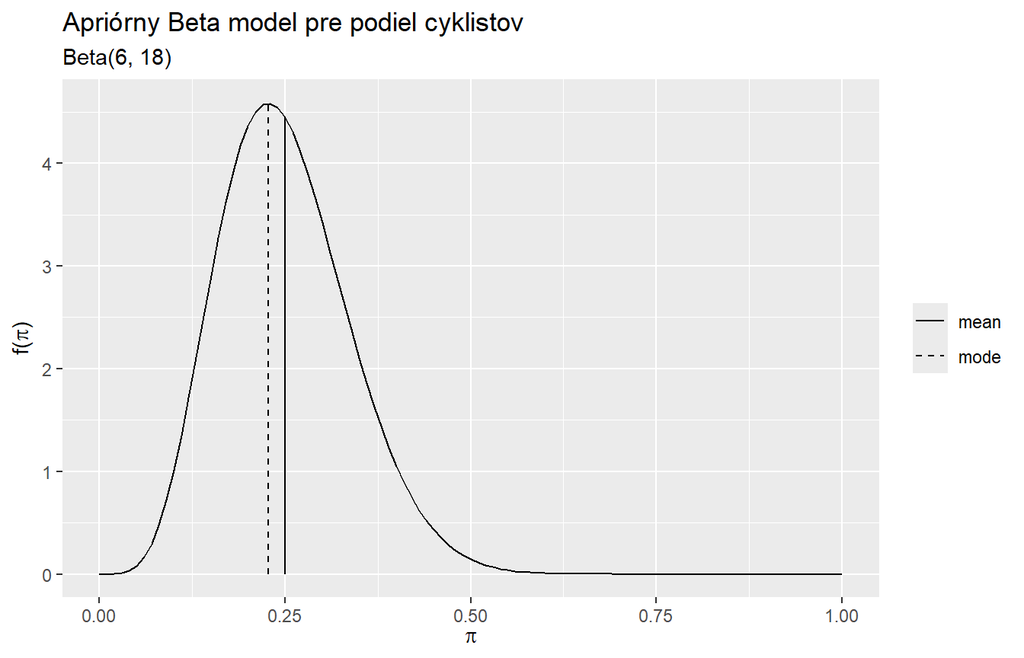

```r
plot_beta(alpha = alpha_prior, beta = beta_prior, mean = TRUE, mode = TRUE) +
  labs(
    title = "Apriórny Beta model pre podiel cyklistov",
    subtitle = paste0("Beta(", alpha_prior, ", ", beta_prior, ")")
  )
```

### b. Posteriórny model pre $\pi$

#### Beta-Binomial model

Pre Beta-Binomial model platí:

> **Prior:**
> $$\begin{equation}
> \pi \sim \text{Beta}(\alpha, \beta)
> \end{equation}$$

> **Dáta:**
> $$\begin{equation}
> Y | \pi \sim \text{Bi}(n = 50, \pi)
> \end{equation}$$

> **Posterior:**
> $$\begin{equation}
> \pi | Y = 15 \sim \text{Beta}(\alpha + y, \beta + n - y)
> \end{equation}$$

#### Výpočet posterioru

Máme: - Prior: Beta(6, 18) - Dáta: $y = 15$ úspechov z $n = 50$ pokusov

Posterior:
$$\begin{align}
\alpha_{post} &= \alpha + y = 6 + 15 = 21 \\
\beta_{post} &= \beta + n - y = 18 + 50 - 15 = 53
\end{align}$$

> **Posteriórny model:**
> $$\begin{equation}
> \boxed{\pi | y \sim \text{Beta}(21, 53)}
> \end{equation}$$

```r
# Dáta
n <- 50
y <- 15

# Posteriórne parametre
alpha_post <- alpha_prior + y
beta_post <- beta_prior + n - y

cat("Posteriórny model: Beta(", alpha_post, ", ", beta_post, ")\n", sep = "")
```

```
## Posteriórny model: Beta(21, 53)
```

### c. Charakteristiky posteriórneho modelu

**Výpočet charakteristík posteriórneho modelu pomocou vzorcov:**

$$\begin{align}
E(\pi | y) &= \frac{21}{21 + 53} = \frac{21}{74} \approx 0.2838 \\
\text{Mode}(\pi | y) &= \frac{21 - 1}{21 + 53 - 2} = \frac{20}{72}
\approx 0.2778 \\
\text{Var}(\pi | y) &= \frac{21 \times 53}{74^2 \times 75} \approx
0.0027 \\
\text{SD}(\pi | y) &= \sqrt{0.0027} \approx 0.0518
\end{align}$$

#### Charakteristiky posteriórneho modelu a porovnanie s apriórnym

```r
summarize_beta(alpha_post, beta_post)
```

```
##        mean      mode         var         sd
## 1 0.2837838 0.2777778 0.002710007 0.05205773
```

```r
summarize_beta_binomial(alpha = alpha_prior, beta = beta_prior, y = y, n = n)
```

```
##       model alpha beta      mean      mode         var         sd
## 1     prior     6   18 0.2500000 0.2272727 0.007500000 0.08660254
## 2 posterior    21   53 0.2837838 0.2777778 0.002710007 0.05205773
```

### d. Porovnanie apriórneho a posterórneho modelu

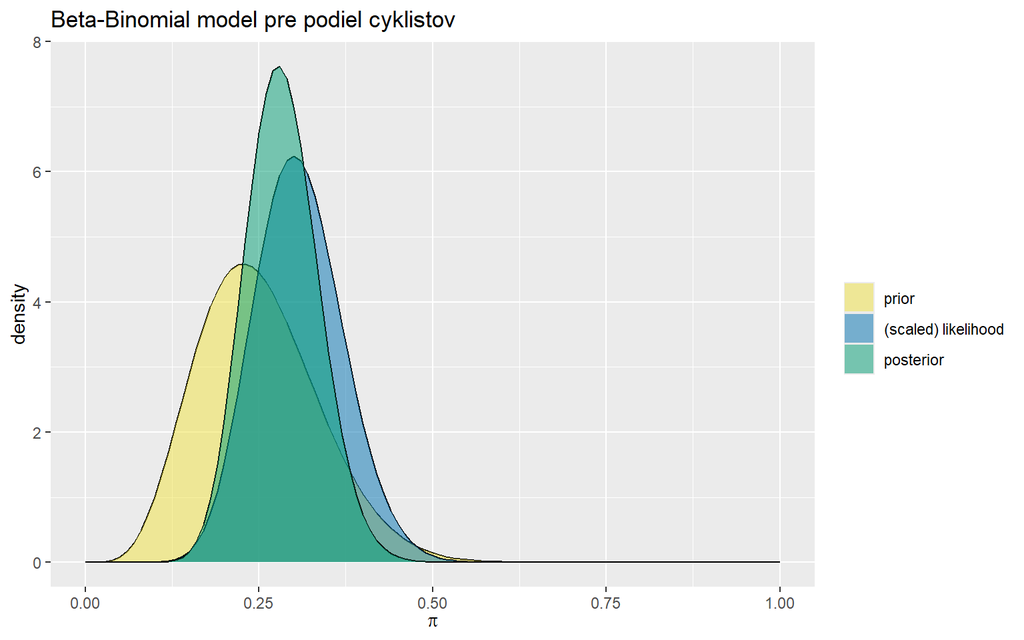

```r
plot_beta_binomial(alpha = alpha_prior, beta = beta_prior, y = y, n = n) +
  labs(title = "Beta-Binomial model pre podiel cyklistov")
```

**Váhy prioru a dát:**

Posteriórnu strednú hodnotu môžeme vyjadriť ako váženú priemer prioru a dát:

$$\begin{align}
E(\pi|y) &= \frac{\alpha + y}{\alpha + \beta + n} = \\
&= \frac{\alpha}{\alpha + \beta + n} + \frac{y}{\alpha + \beta + n}
= \\
&= \frac{\alpha + \beta}{\alpha + \beta + n} \cdot
\frac{\alpha}{\alpha + \beta} + \frac{n}{\alpha + \beta + n} \cdot
\frac{y}{n} = \\
&= w_{prior} \cdot E(\pi) + w_{data} \cdot \frac{y}{n}
\end{align}$$

Zjednodušene:
$$\begin{equation}
E(\pi|y) \approx w_{prior} \cdot E(\pi) + w_{data} \cdot \frac{y}{n}
\end{equation}$$
kde váhy sú určené “silou” apriórneho modelu ($\alpha + \beta$) a počtom dát ($n$).

Sila prioru:
$$\begin{equation}
\alpha + \beta = 6 + 18 = 24
\end{equation}$$

Sila dát:
$$\begin{equation}
n = 50
\end{equation}$$

Váha prioru:
$$\begin{equation}
w_{prior} =\frac{\alpha + \beta}{\alpha + \beta + n} = \frac{6 + 18}{6 +
18 + 50} = \frac{24}{74} = 0.3243
\end{equation}$$

Váha dát:
$$\begin{equation}
w_{data} =\frac{n}{\alpha + \beta + n} = \frac{50}{6 + 18 + 50} =
\frac{50}{74} = 0.6757
\end{equation}$$

Vážený priemer:
$$\begin{equation}
E(\pi|y) = \frac{24}{74} \cdot \frac{1}{4} + \frac{50}{74} \cdot
\frac{15}{50} = 0.2838
\end{equation}$$

Podiel v apriórnom modeli:
$$\begin{equation}
\pi = \frac{6}{6 + 18} = 0.25
\end{equation}$$

Podiel - dáta:
$$\begin{equation}
\pi = \frac{15}{50} = 0.3
\end{equation}$$

**Posterior je bližšie k dátam ako k prioru.**

### Graf - posteriórny model

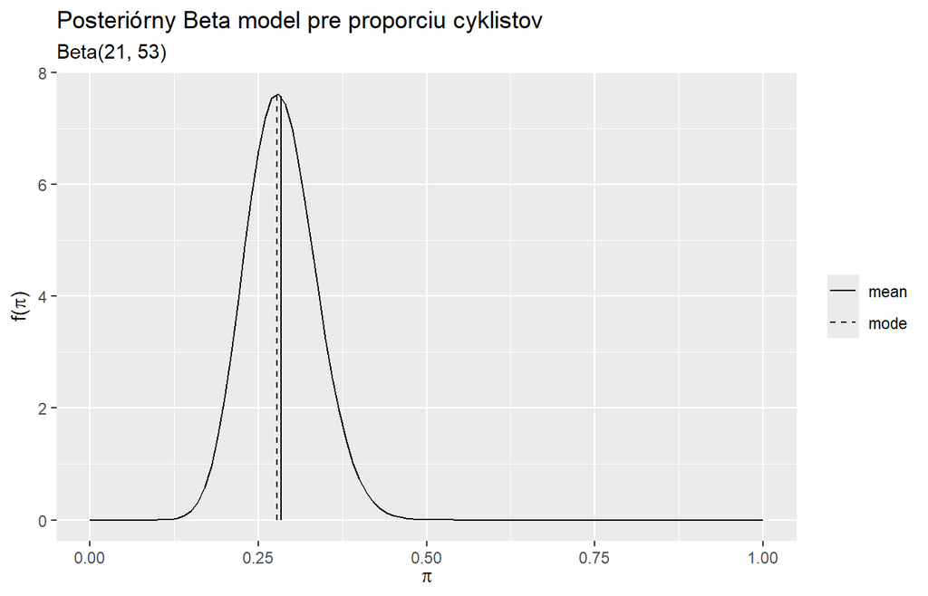

```r
plot_beta(alpha = alpha_post, beta = beta_post, mean = TRUE, mode = TRUE) +
  labs(
    title = "Posteriórny Beta model pre proporciu cyklistov",
    subtitle = paste0("Beta(", alpha_post, ", ", beta_post, ")")
  )
```

Personál univerzity si myslel, že približne 25% študentov pravidelne jazdí na bicykli. V prieskume 50 študentov bolo 15 cyklistov (30%).  
Po aktualizácii dátami máme posteriórny model so strednou hodnotou podielu 28.4% - Je to medzi priorom (25%) a dátami (30%) - Bližšie k dátam, pretože dáta mali väčšiu váhu

SD klesla, graf sa zúžil - máme väčšiu istotu

# Exercise 4.18: A Sequential Employee

*Zdroj: [Exercise 4.18](https://www.bayesrulesbook.com/chapter-4#exercises-3)*

> Obuvnícka spoločnosť opísaná v Cvičení 4.17 prijíma štvrtého zamestnanca. Začína s rovnakým apriórnym rozdelením Beta(4, 3) pre $\pi$ ako prví traja zamestnanci, ale keďže nechce duplikovať prácu, nezbiera vlastné dáta. Namiesto toho v prvý deň v práci nový zamestnanec presvedčí prvého zamestnanca, aby mu poskytol svoje dáta. Na druhý deň získa prístup k dátam druhého zamestnanca a na tretí deň získa prístup k dátam tretieho zamestnanca.
> 1. Predpokladajme, že nový zamestnanec aktualizuje svoj posteriórny model $\pi$ na konci každého dňa. Aký je jeho posterior na konci prvého dňa? Na konci druhého dňa? Na konci tretieho dňa?
> 2. Načrtnite prior nového zamestnanca a tri (sekvenčné) posteriory. Slovne opíšte, ako sa jeho chápanie $\pi$ vyvíjalo počas prvých troch dní v práci.
> 3. Predpokladajme, že nový zamestnanec by namiesto toho svoj posterior neaktualizoval až do konca svojho tretieho dňa v práci, po tom, čo získal dáta od všetkých troch ostatných zamestnancov. Špecifikujte jeho posteriórny model $\pi$ a porovnajte ho s posteriorom z tretieho dňa z časti (a).

## Solution

Parameter $\pi$ = pravdepodobnosť, že používateľ klikne na reklamu.

**Všetci zamestnanci majú rovnaký apriórny model:**
$$\begin{equation}
\pi \sim \text{Beta}(4, 3)
\end{equation}$$

**Štvrtý zamestnanec (dáta zo 4.17):**

- Začína s rovnakým priorom Beta(4, 3)
- Získava dáta postupne od kolegov:
  - **Deň 1:** Dáta od zamestnanca 1 (0 kliknutí z 1 pokusu)
  - **Deň 2:** Dáta od zamestnanca 2 (3 z 10 pokusov)
  - **Deň 3:** Dáta od zamestnanca 3 (20 zo 100 pokusov)

### a. Sekvenčná aktualizácia posterioru

**Prior pre štvrtého zamestnanca:**
$$\begin{equation}
\pi \sim \text{Beta}(4, 3)
\end{equation}$$

#### Update beta-binomického modelu

**Prior:**
$$\begin{equation}
\pi \sim \text{Beta}(\alpha, \beta)
\end{equation}$$

**Dáta:**
$$\begin{equation}
Y | \pi \sim \text{Binomial}(n, \pi)
\end{equation}$$

**Posterior:**
$$\begin{equation}
\pi | Y = y \sim \text{Beta}(\alpha + y, \beta + n - y)
\end{equation}$$

**Pri sekvenčnej analýze:** Posterior z jedného dňa sa stáva priorom pre ďalší deň

#### Deň 1: Dáta od zamestnanca 1

**Prior na začiatku dňa 1:** Beta(4, 3)

**Dáta od zamestnanca 1:** $y_1 = 0$ kliknutí z $n_1 = 1$ pokusu

**Posterior na konci dňa 1:**
$$\begin{align}
\alpha_1 &= 4 + 0 = 4 \\
\beta_1 &= 3 + 1 - 0 = 4
\end{align}$$

$$\begin{equation}
\boxed{\pi_\text{deň 1} \sim \text{Beta}(4, 4)}
\end{equation}$$

#### Aktualizácia beta modelu po prvom dni

```
##       model alpha beta      mean mode        var        sd
## 1     prior     4    3 0.5714286  0.6 0.03061224 0.1749636
## 2 posterior     4    4 0.5000000  0.5 0.02777778 0.1666667
```

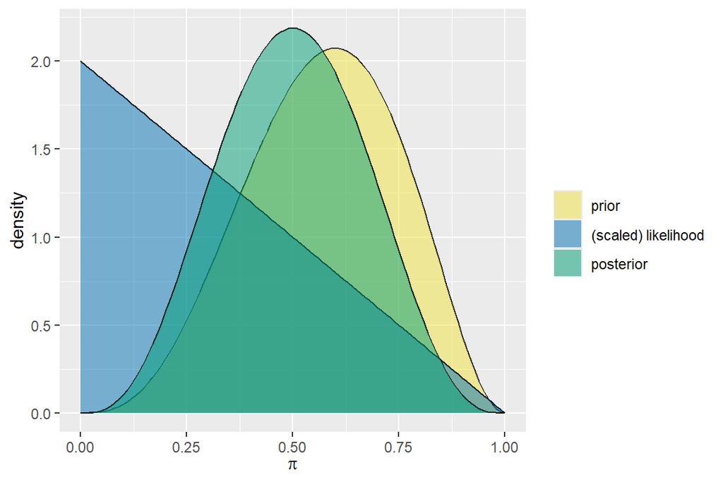

#### Deň 2: Dáta od zamestnanca 2

**Prior na začiatku dňa 2:** Beta(4, 4) (posterior z dňa 1)

**Dáta od zamestnanca 2:** $y_2 = 3$ kliknutia z $n_2 = 10$ pokusov

**Posterior na konci dňa 2:**
$$\begin{align}
\alpha_2 &= 4 + 3 = 7 \\
\beta_2 &= 4 + 10 - 3 = 11
\end{align}$$

$$\begin{equation}
\boxed{\pi_\text{deň 2} \sim \text{Beta}(7, 11)}
\end{equation}$$

```
##       model alpha beta      mean  mode        var        sd
## 1     prior     4    4 0.5000000 0.500 0.02777778 0.1666667
## 2 posterior     7   11 0.3888889 0.375 0.01250812 0.1118397
```

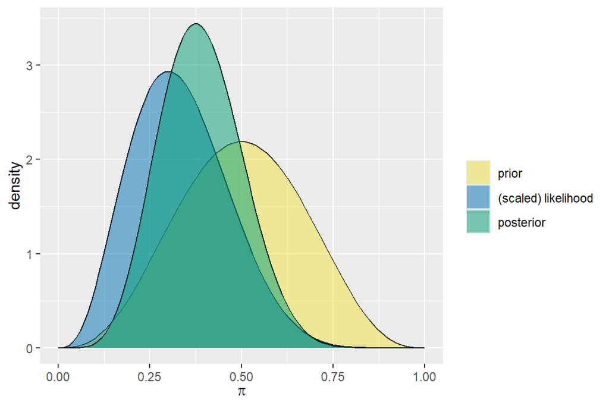

#### Deň 3: Dáta od zamestnanca 3

**Prior na začiatku dňa 3:** Beta(7, 11) (posterior z dňa 2)

**Dáta od zamestnanca 3:** $y_3 = 20$ kliknutí z $n_3 = 100$ pokusov

**Posterior na konci dňa 3:**
$$\begin{align}
\alpha_3 &= 7 + 20 = 27 \\
\beta_3 &= 11 + 100 - 20 = 91
\end{align}$$

$$\begin{equation}
\boxed{\pi_\text {deň 3} \sim \text{Beta}(27, 91)}
\end{equation}$$

```
##       model alpha beta      mean      mode        var         sd
## 1     prior     7   11 0.3888889 0.3750000 0.01250812 0.11183972
## 2 posterior    27   91 0.2288136 0.2241379 0.00148284 0.03850766
```

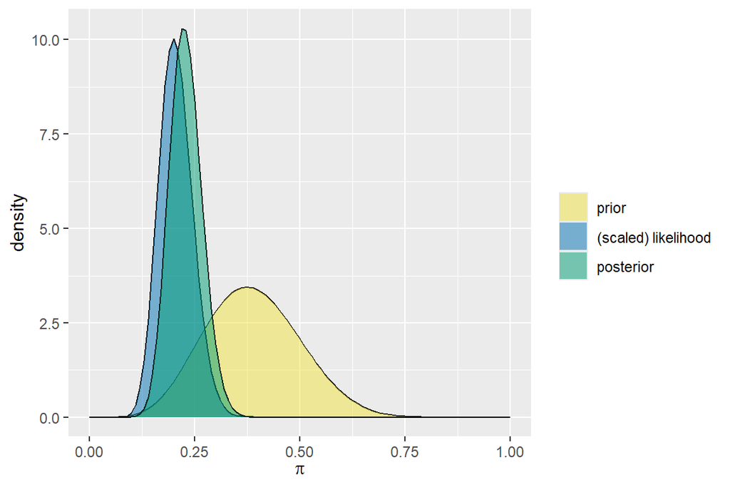

#### Sumár sekvenčnej aktualizácie

```r
summary_seq <- data.frame(
  Den = c("Prior", "Deň 1", "Deň 2", "Deň 3"),
  Model = c(
    paste0("Beta(", prior$a, ", ", prior$b, ")"),
    paste0("Beta(", posterior1$a, ", ", posterior1$b, ")"),
    paste0("Beta(", posterior2$a, ", ", posterior2$b, ")"),
    paste0("Beta(", posterior3$a, ", ", posterior3$b, ")")
  ),
  Data = c(
    " - ",
    paste0(employee_1$y, " z ", employee_1$n),
    paste0(employee_2$y, " z ", employee_2$n),
    paste0(employee_3$y, " z ", employee_3$n)
  ),
  Mean = c(prior$mean, posterior1$mean, posterior2$mean, posterior3$mean),
  SD = c(prior$SD, posterior1$SD, posterior2$SD, posterior3$SD)
)

summary_seq <- summary_seq %>%
  mutate(across(c(Mean, SD), ~round(.x, 4)))

knitr::kable(summary_seq, caption = "Sekvenčná aktualizácia posterioru")
```

Sekvenčná aktualizácia posterioru

| Den | Model | Data | Mean | SD |
| --- | --- | --- | --- | --- |
| Prior | Beta(4, 3) | - | 0.5714 | 0.1750 |
| Deň 1 | Beta(4, 4) | 0 z 1 | 0.5000 | 0.1667 |
| Deň 2 | Beta(7, 11) | 3 z 10 | 0.3889 | 0.1118 |
| Deň 3 | Beta(27, 91) | 20 z 100 | 0.2288 | 0.0385 |

### b. Vizualizácia sekvenčnej zmeny

#### Graf všetkých modelov

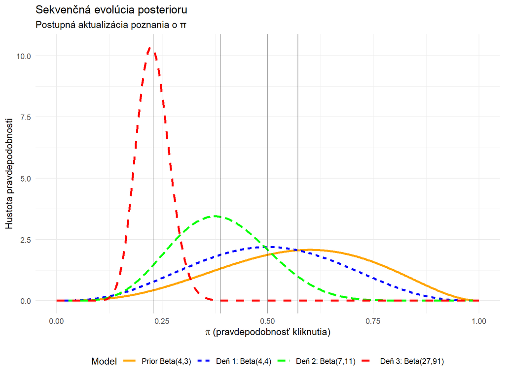

```r
# Vytvorenie dát pre grafy
pi_vals <- seq(0, 1, length.out = 501)

# Hustoty pre všetky modely
prior$density <- dbeta(pi_vals, prior$a, prior$b)
posterior1$density <- dbeta(pi_vals, posterior1$a, posterior1$b)
posterior2$density <- dbeta(pi_vals, posterior2$a, posterior2$b)
posterior3$density <- dbeta(pi_vals, posterior3$a, posterior3$b)

# Data frame pre ggplot
df_sequential <- data.frame(
  pi = rep(pi_vals, 4),
  density = c(prior$density, posterior1$density, posterior2$density, posterior3$density),
  Model = rep(c("Prior Beta(4,3)",
                "Deň 1: Beta(4,4)",
                "Deň 2: Beta(7,11)",
                "Deň 3: Beta(27,91)"),
              each = length(pi_vals))
)

# Určenie správneho poradia
df_sequential$Model <- factor(df_sequential$Model,
                              levels = c("Prior Beta(4,3)",
                                        "Deň 1: Beta(4,4)",
                                        "Deň 2: Beta(7,11)",
                                        "Deň 3: Beta(27,91)"))

# Graf
ggplot(df_sequential, aes(x = pi, y = density, color = Model, linetype = Model)) +
  geom_line(size = 1.1) +
  labs(
    title = "Sekvenčná evolúcia posterioru",
    subtitle = "Postupná aktualizácia poznania o π",
    x = expression(pi ~ "(pravdepodobnosť kliknutia)"),
    y = "Hustota pravdepodobnosti",
    color = "Model",
    linetype = "Model"
  ) +
  theme_minimal() +
  theme(legend.position = "bottom") +
  scale_color_manual(values = c("orange", "blue", "green", "red")) +
  geom_vline(xintercept = c(prior$mean, posterior1$mean, posterior2$mean, posterior3$mean),
             linetype = "solid", alpha = 0.3)
```

### c. Porovnanie sekvenčnej vs. jednorázovej aktualizácie

#### Jednorázová aktualizácia (všetky dáta naraz)

Čo keby štvrtý zamestnanec čakal do konca dňa 3 a aktualizoval prior všetkými dátami naraz?

**Prior:** Beta(4, 3)

**Všetky dáta spolu:**
$$\begin{align}
y_{total} &= y_1 + y_2 + y_3 = 0 + 3 + 20 = 23 \\
n_{total} &= n_1 + n_2 + n_3 = 1 + 10 + 100 = 111
\end{align}$$

$$\begin{equation}
\boxed{\pi | \text{všetky dáta} \sim \text{Beta}(27, 91)}
\end{equation}$$

```r
# Jednorazová aktualizácia
employees <- list(y = employee_1$y + employee_2$y + employee_3$y, n = employee_1$n + employee_2$n + employee_3$n)
a <- prior$a + employees$y
b <- prior$b + employees$n - employees$y

total <- list (a = a,
               b = b,
               mean = a/(a + b),
               SD = sqrt((a * b) / ((a + b)^2 * (a + b + 1))),
               mode = (a - 1)/(a + b - 2))

summarize_beta_binomial(alpha = prior$a, beta = prior$b, y = employees$y, n = employees$n)
```

```
##       model alpha beta      mean      mode        var         sd
## 1     prior     4    3 0.5714286 0.6000000 0.03061224 0.17496355
## 2 posterior    27   91 0.2288136 0.2241379 0.00148284 0.03850766
```

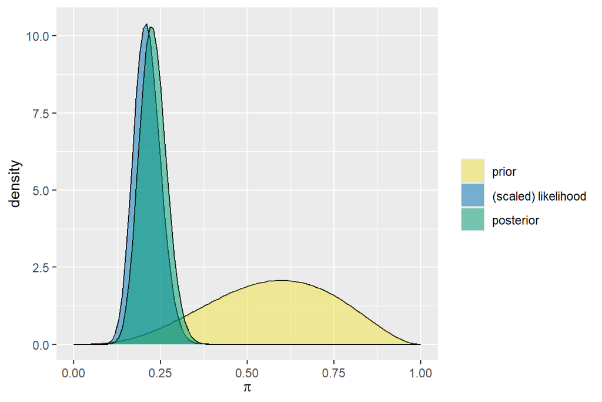

```r
plot_beta_binomial(alpha = prior$a, beta = prior$b, y = employees$y, n = employees$n)
```

#### Porovnanie výsledkov

```r
comparison <- data.frame(
  Metoda = c("Sekvenčná (3 dni)", "Jednorázová (všetky dáta)"),
  Model = c(
    paste0("Beta(", posterior3$a, ", ", posterior3$b, ")"),
    paste0("Beta(", total$a, ", ", total$b, ")")
  ),
  Mean = c(posterior3$mean, total$mean),
  SD = c(posterior3$SD, total$SD)
)

comparison <- comparison %>%
  mutate(across(c(Mean, SD), ~round(.x, 4)))

knitr::kable(comparison, caption = "Porovnanie sekvenčnej a jednorázovej aktualizácie")
```

Porovnanie sekvenčnej a jednorázovej aktualizácie

| Metoda | Model | Mean | SD |
| --- | --- | --- | --- |
| Sekvenčná (3 dni) | Beta(27, 91) | 0.2288 | 0.0385 |
| Jednorázová (všetky dáta) | Beta(27, 91) | 0.2288 | 0.0385 |

**Záver:**

$$\begin{equation}
\text{Beta}(27, 91)_{\text{sekvenčná}} = \text{Beta}(27,
91)_{\text{jednorázová}}
\end{equation}$$

- Finálny posterior je **nezávislý na poradí** dát
- Nezáleží na tom, či dáta spracujeme **postupne** alebo **naraz**
- Matematicky:

$$\begin{equation}
\text{Beta}(\alpha, \beta) \xrightarrow{y_1, n_1} \text{Beta}(\alpha +
y_1, \beta + n_1 - y_1) \xrightarrow{y_2, n_2} \text{Beta}(\alpha + y_1
+ y_2, \beta + n_1 - y_1 + n_2 - y_2) \xrightarrow{y_3, n_3} \cdots
\end{equation}$$

je ekvivalentné s:

$$\begin{equation}
\text{Beta}(\alpha, \beta) \xrightarrow{y_{total}, n_{total}}
\text{Beta}(\alpha + y_{total}, \beta + n_{total} - y_{total})
\end{equation}$$

# Exercise 5.7: World Cup

*Zdroj: [Exercise 5.7](https://www.bayesrulesbook.com/chapter-5#exercises-4)*

> Nech $\lambda$ je priemerný počet strelených gólov v zápase na Majstrovstvách sveta žien. Budeme analyzovať $\lambda$ pomocou nasledujúceho Gamma-Poissonovho modelu, kde dáta $Y_i$ predstavujú pozorovaný počet gólov vo vzorke zápasov Svetového pohára:
> $$\begin{split}
> Y_i | \lambda & \stackrel{ind}{\sim} \text{Pois}(\lambda) \\
> \lambda & \sim \text{Gamma}(1, 0.25) \\
> \end{split}$$
> 1. Vykreslite a zhrňte naše apriórne chápanie $\lambda$.
> 2. Prečo je Poissonov model rozumnou voľbou pre naše dáta $Y_i$?
> 3. Dáta `wwc_2019_matches` v balíčku fivethirtyeight zahŕňajú počet gólov, ktoré strelili oba tímy v každom zápase na Majstrovstvách sveta žien v roku 2019. Definujte, vykreslite a prediskutujte celkový počet gólov strelených za zápas.
> 4. Identifikujte posteriórny model $\lambda$ a overte svoju odpoveď pomocou `summarize_gamma_poisson()`.
> 5. Vykreslite apriórnu funkciu hustoty, vierohodnostnú funkciu a posteriórnu funkciu hustoty $\lambda$. Opíšte vývoj vo vašom chápaní $\lambda$ od prioru k posterioru.

## Solution

### a. Apriórny model Gamma pre $\lambda$

Náhodná premenná $\lambda$ reprezentuje počet gólov za jeden zápas.Tento počet gólov je modelovaný rozdelením $Gamma(s = 1, r = 0.25)$.

> **Pre Gamma rozdelenie platí:**
> $$\begin{equation}
> \begin{split}
> E(\lambda) & = \frac{s}{r} = \frac{1}{0.25} = 4 \\
> \text{Mode}(\lambda) & = \frac{s - 1}{r} = \frac{1 - 1}{0.25} = 0 \\
> \text{Var}(\lambda) & = \frac{s}{r^2} = \frac{1}{0.25^2} = 16 \\
> \end{split}
> \end{equation}$$

```r
# Číselné charakteristiky pre Gamma model
summarize_gamma(s, r)
```

```
##   mean mode var sd
## 1    4    0  16  4
```

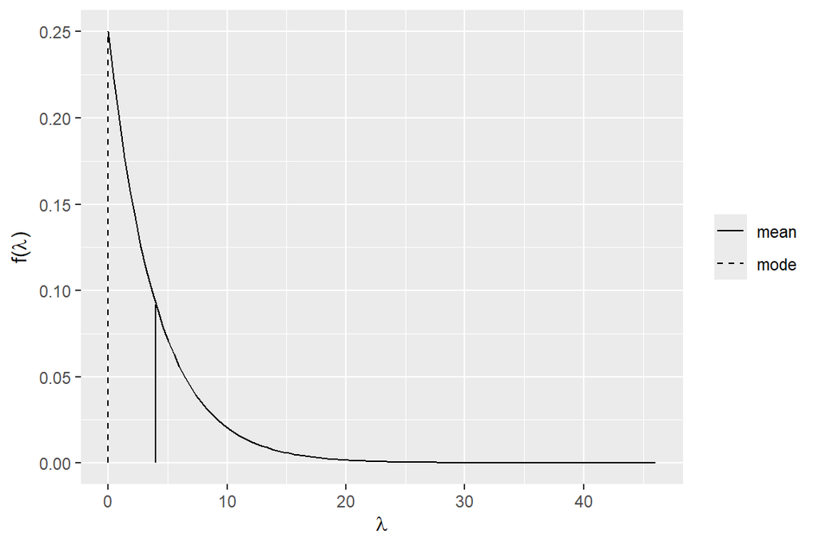

```r
# Gamma model v grafe
plot_gamma(shape = s, rate = r, mean = TRUE, mode = TRUE)
```

### b. Prečo Poissonov model?

Náhodná premenná $Y_i$ predstavuje koľkokrát nastane gól, t.j. nejaký jav počas zápasu. Táto premenná nemá horné ohraničenie z nejakého počtu pokusov, pri ktorom niečo stane / nenastane. Preto je vhodné modelovať to Poissonovým rozdelením.

### c. Dáta: Celkové počty gólov za zápas

```r
# Frequency
wwc_2019_matches %>% count(total_goals)
```

```
## # A tibble: 8 × 2
##   total_goals     n
##         <dbl> <int>
## 1           0     2
## 2           1    10
## 3           2    10
## 4           3    20
## 5           4     4
## 6           5     3
## 7           6     2
## 8          13     1
```

```r
data <- wwc_2019_matches %>% select(total_goals)

# Descriptive characteristics
cat('Súčet gólov:',sum(data$total_goals), '\n',
    'Priemer gólov:',mean(data$total_goals), '\n',
    'Rozptyl:',var(data$total_goals), '\n',
    'Počet zápasov:',length(data$total_goals), '\n')
```

```
## Súčet gólov: 146
##  Priemer gólov: 2.807692
##  Rozptyl: 3.923077
##  Počet zápasov: 52
```

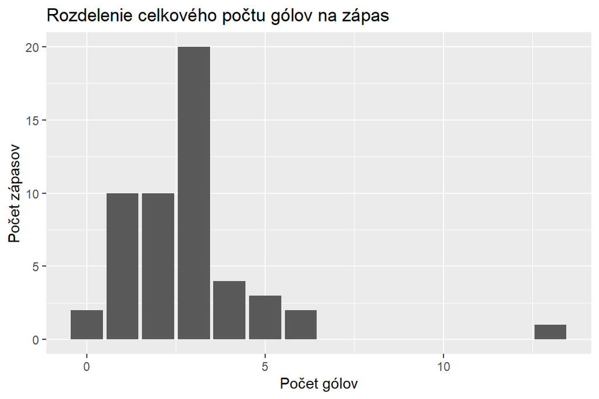

```r
# Histogram
ggplot(data, aes(x = total_goals)) +
  geom_bar() +
  labs(title = "Rozdelenie celkového počtu gólov na zápas",
       x = "Počet gólov", y = "Počet zápasov")
```

Priemerný počet gólov počas jedného zápasu je okolo 3. Stred apriórneho modelu bol 4. Rozptyl je teraz menší.

Pravdepodobnosť roznych hodnot pre $\lambda$ na základe dát o góloch možeme vidieť v grafe pre vierohodnostnú funkciu (neškálovanú).

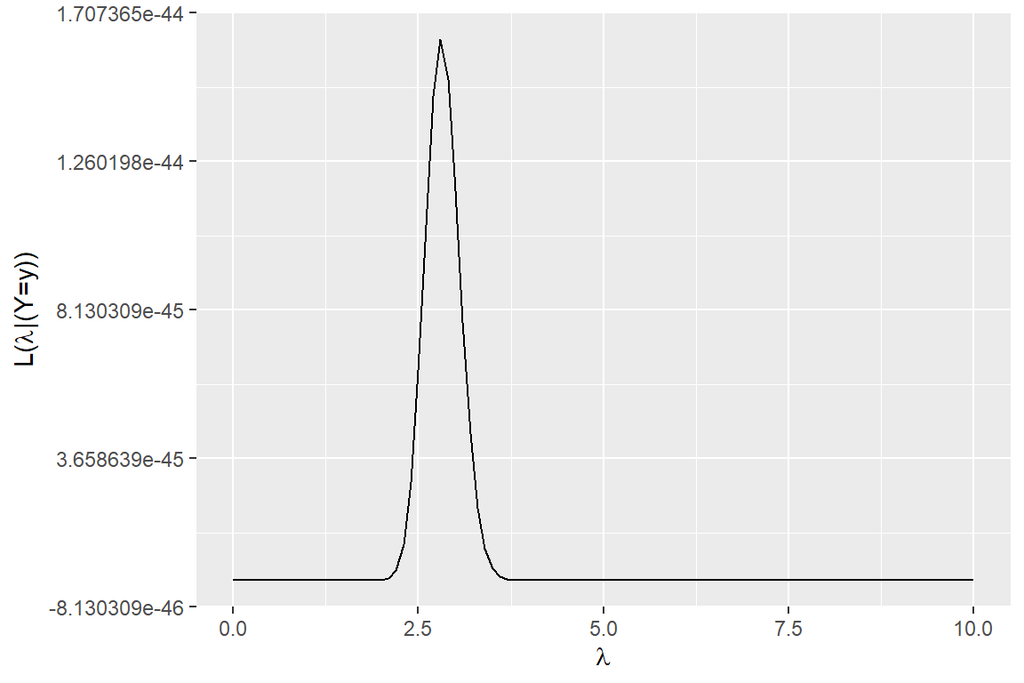

```r
# Vierohodnostná funkcia
plot_poisson_likelihood(y = data$total_goals)
```

### d. Posteriórny model

Posteriorny model je proporcionálny súčinu apriorneho modelu a vierohodnostného modelu:

> Na začiatku apriórny model, ktorý má Gamma rozdelenie:
> $$\begin{split}
> \lambda & \sim \text{Gamma}\left(s = 1, r = 0.25\right) \\
> \end{split}$$

> Jednotlivé pozorovania majú Poissonovo rozdelenie:
> $$\begin{split}
> Y_i | \lambda & \stackrel{ind}{\sim} \text{Pois}(\lambda) \\
> \end{split}$$

```
## Prior: s =  1 , r = 0.25 ,
## Dáta: počet gólov = 146 , počet zápasov = 52
```

> Posteriórny model je tiež Gamma s parametrami:
> $$\begin{equation}
> \lambda|\vec{y} \; \sim \; \text{Gamma}\left(s + \sum y_i, \; r +
> n\right) = \\
> \lambda|\vec{y} \; \sim \; \text{Gamma}\left(1 + 146 = 147, \; 0.25 +
> 52\right) \\
> \lambda|\vec{y} \; \sim \; \text{Gamma}\left(147, \; 52.25\right) \\
> \end{equation}$$
> kde $y_i$ sú jednotlivé počty gólov a $n$ je počet zápasov.

> **Posterior Gamma rozdelenie má teda vlastnosti:**
> $$\begin{equation}
> \begin{split}
> E(\lambda) & = \frac{s}{r} = \frac{147}{52.2} \approx 2.81 \\
> \text{Mode}(\lambda) & = \frac{s - 1}{r} = \frac{147 - 1}{52.2}
> \approx 2.79 \\
> \text{Var}(\lambda) & = \frac{s}{r^2} = \frac{147}{52.2^2} \approx
> 0.054 \\
> \end{split}
> \end{equation}$$

**Prior vs. posterior** Porovnanie charakteristík apriórneho a posteriórneho Gamma modelu

```
##       model shape  rate     mean     mode         var        sd
## 1     prior     1  0.25 4.000000 0.000000 16.00000000 4.0000000
## 2 posterior   147 52.25 2.813397 2.794258  0.05384492 0.2320451
## 3      data    NA    NA 2.807692 3.000000  3.92307692 1.9806759
```

**Interpretácia:** Apriórne a aposteriórne rozdelenie sú kongujované, t.j. rovnakého typu.

### e. Graf - porovnanie modelov

V grafe vidíme rozdelenia všetkých troch modelov: apriórny, vierohodnosť, posteriórny

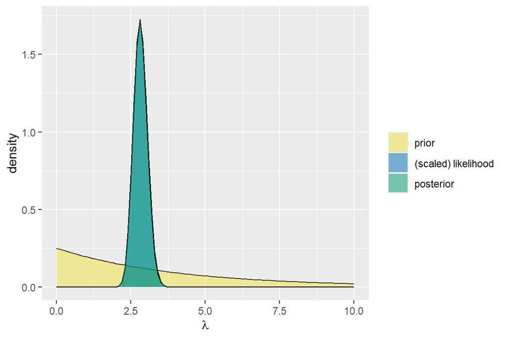

Vidíme, že postreriórny model v podstate celkom prekryl vierohodnostný model. To je preto, že: - máme pomerne veľa dát - 52 zápasov - prior bol málo informatívny (veľký rozptyl, nízke hodnoty $s$ a $r$) - teda dáta dominujú, čiže posteriórne rozdelenie je približne rovnaké ako vierohodnostné

#### Len posteriorný model

Ak chceme detailne pozrieť rozdelenie pre posteriórny model, zobrazíme ho ako apriórny so zmenenými charakteristikami podľa vzťahu pre (posterior).

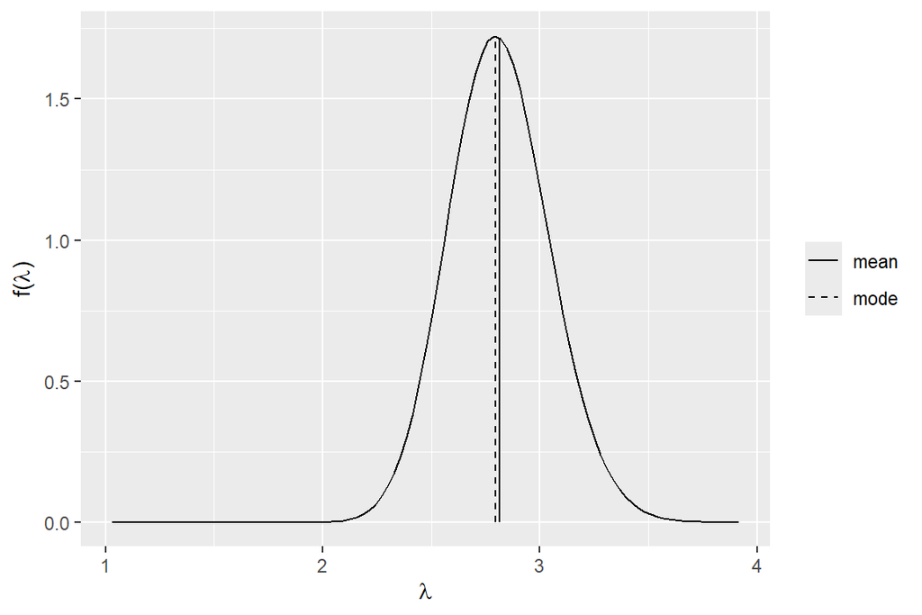

```r
# Vizualizácia posteriorného modelu
plot_gamma(shape = s + sum(data$total_goals), rate = r + length(data$total_goals), mean = TRUE, mode = TRUE)
```

# Exercise 5.9: Investing in Stock

Riešenie cvičenia 5.9 z knihy [Bayes Rules!](https://www.bayesrulesbook.com/chapter-5#exercises-4) Modelovanie ceny investície počas dňa normálnym rozdelením  
a cvičenia 5.10 z rovnakej knihy Update apriórneho modelu o dáta

*Zdroj: [Exercise 5.9](https://www.bayesrulesbook.com/chapter-5#exercises-4)*

> Práve ste kúpili akcie spoločnosti FancyTech. Nech náhodná premenná $\mu$ je priemerná suma v dolároch, o ktorú vaša akcia FancyTech stúpne alebo klesne za jeden deň. Spočiatku veríte, že $\mu$ je 7.2 dolárov so smerodajnou odchýlkou 2.6 dolárov.  
> a. Nalaďte a vykreslite vhodný normálny apriórny model pre $\mu$.  
> b. Podľa vášho grafu, zdá sa byť pravdepodobné, že by akcia FancyTech stúpla v priemere o 7.6 dolárov za deň?  
> c. Zdá sa byť pravdepodobné, že by akcia FancyTech stúpla v priemere o 4 doláre za deň?  
> d. Aká je apriórna pravdepodobnosť, že v priemere cena akcie klesne? Pomôcka: `pnorm()`.  
> e. Aká je apriórna pravdepodobnosť, že v priemere vaša cena akcie stúpne o viac ako 8 dolárov za deň?

## Solution:

### a. Apriórny model Normal pre $\mu$

Na začiatku veríme, že stredná hodnota je 7.2 a odchýlka 2.6. To sú teda parametre apriórneho normálneho modelu. Smerodajná odchýlka vyjadruje našu neistotu ohľadom strednej hodnoty.  
**Hyperparametre:** $\theta$ = apriorna stredná hodnota pre $\mu$  
$\tau$ = apriórna smerodajná odchýlka (miera neistoty v odhade $\mu$)

> $$\begin{equation}
> \begin{split}
> \mu \sim N(\theta = 7.2, \tau^2 = 2.6^2)
> \end{split}
> \end{equation}$$

#### Graf - apriórny model:

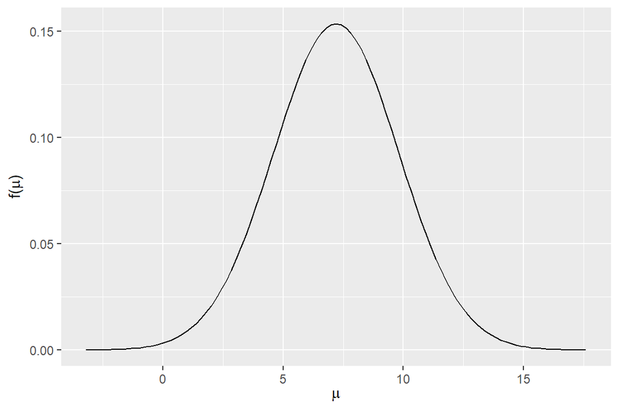

### b. Vierohodnosť hodnoty 7.6

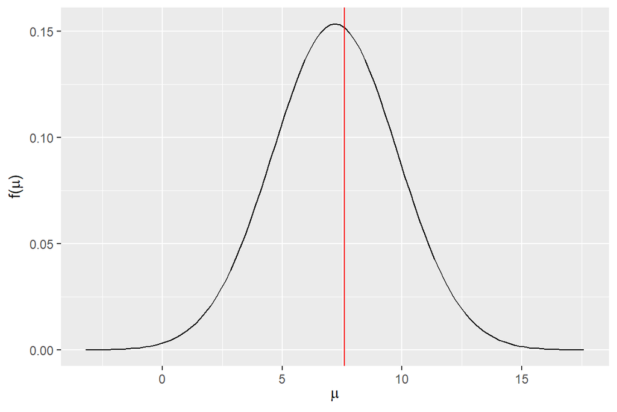

```
## Výška krivky v bode 7.6 je 0.1516342
##  Výška krivky v strednej hodnote je 0.1534393
##  Vzdialenosť hodnoty 7.6 od strednej hodnoty je 0.1538462 -násobok smerodajnej odchýlky.
```

Hodnota 7.6 je blízko strednej hodnoty 7.2. Je teda vysoko vierohodná.

### c. Vierohodnosť hodnoty 4

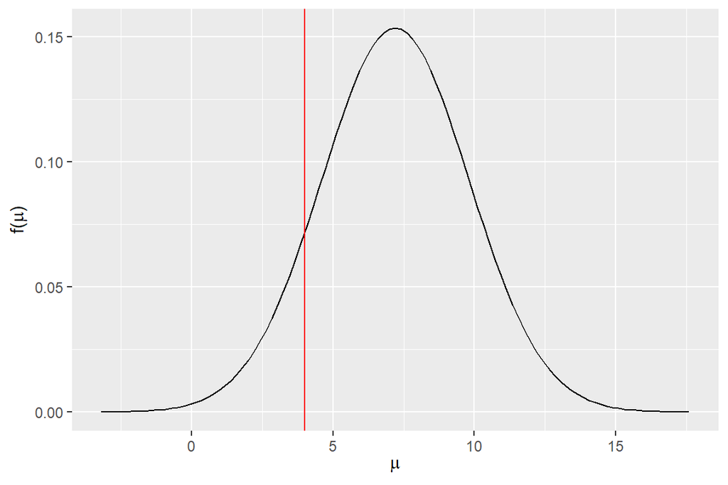

```
## Výška krivky v bode 4 je 0.0719455
```

```
## Výška krivky v strednej hodnote je 0.1534393
```

```
## Vzdialenosť hodnoty 4 od strednej hodnoty je 1.230769-násobok smerodajnej odchýlky.
```

Hodnota 4 je ďalej od strednej hodnoty 7.2. Je teda oveľa menej vierohodná.

### d. Pravdepodobnosť poklesu

obsah modrej plochy

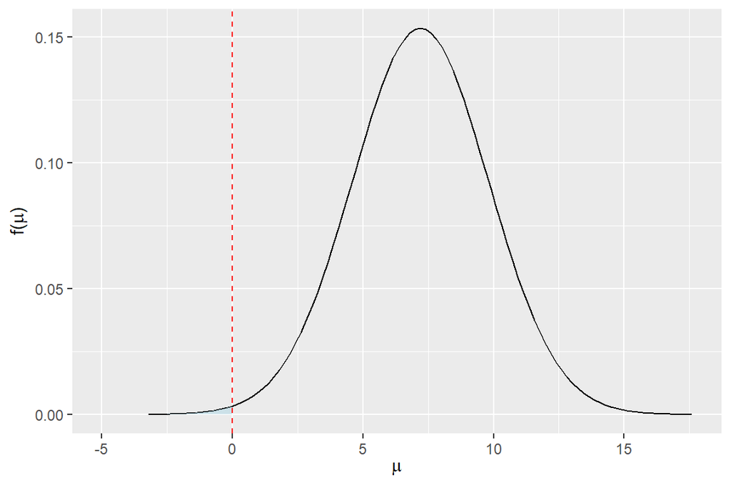

```
## Pravdepodobnosť, že cena bude klesať je 0.0028
```

### e. Pravdepodobnosť rastu o viac ako 8

obsah modrej plochy

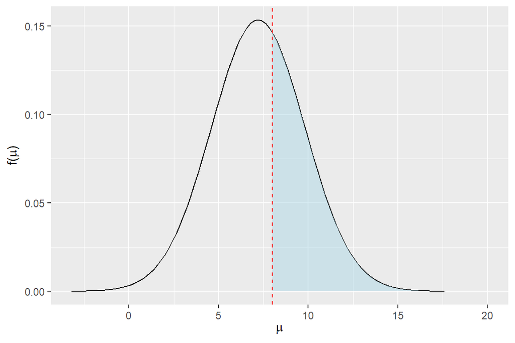

```
## Pravdepodobnosť, že cena bude rásť o viac ako 8 je 0.3792
```

# Exercise 5.10: Investing in Stock with data

*Zdroj: [Exercise 5.10](https://www.bayesrulesbook.com/chapter-5#exercises-4)*

> Pokračujeme v Cvičení 5.9. Je rozumné predpokladať, že denné zmeny hodnoty akcií FancyTech sú normálne rozdelené okolo neznámej strednej hodnoty $\mu$ so známou smerodajnou odchýlkou $\sigma = 2$ doláre. Na náhodnej vzorke 4 dní pozorujete zmeny v hodnote akcií o $-0.7$, $1.2$, $4.5$ a $-4$ doláre.  
> a. Vykreslite zodpovedajúcu vierohodnostnú funkciu pre $\mu$.  
> b. Vykreslite apriórnu funkciu hustoty, vierohodnostnú funkciu a posteriórnu funkciu hustoty pre $\mu$.  
> c. Použite `summarize_normal_normal()` na výpočet popisných štatistík pre apriórny a posteriórny model.  
> d. Okomentujte, ako sa vyvinulo vaše chápanie $\mu$ od prioru (v predchádzajúcom cvičení) k posterioru na základe pozorovaných dát.  
> e. Aká je posteriórna pravdepodobnosť, že v priemere cena akcie klesne? Pomôcka: `pnorm()`.  
> f. Aká je posteriórna pravdepodobnosť, že v priemere vaša cena akcie stúpne o viac ako 8 dolárov za deň?

## Solution:

### a. Vierohodnostný model pre $\mu$

#### Dáta: 4 pozorovania na burze

```r
y <- c(-0.7, 1.2, 4.5, -4)
sd <- 2
```

> Neznámy hyperparameter $\mu$ má normálne rozdelenie.
> $$\begin{equation}
> \mu \sim N(\theta = 7.2, \tau^2 = 2.6^2)
> \end{equation}$$

> Za predpokladu, že poznáme $\mu$, tak zmenu ceny na burze modelujeme normálnym rozdelením. T.j. vierohodnostná funkcia je:
> $$\begin{equation}
> Y | \mu \sim N(\mu, \sigma^2) \\
> \end{equation}$$

> Označme ($Y_1$,$Y_2$,,$Y_n$) zmeny na burze v jednotlivých pozorovaných dňoch. Zmena ceny za jeden deň je **nezávisle** modelovaná normálnym modelom.
> $$\begin{equation}
> Y_i | \mu \stackrel{ind}{\sim} \text{N}(\mu, \sigma^2) \\
> \end{equation}$$

> Neanalyzujeme však každý deň samostatne, využijeme súhrnnú informáciu zo všetkých dní, t.j. máme funkciu združenej hustoty pravdepodobnosti:  
> **Združená hustota pravdepodobnosti**
> - Nech $(Y_1,Y_2,\ldots,Y_n)$ sú nezávislé pozorovania náhodnej premennej a $\vec{y} = (y_1,y_2,\ldots,y_n)$ je vektor týchto pozorovaní
> - $f(y_i | \mu)$ označuje funkciu hustoty pre jedno pozorovanie $Y_i$.

> Za predpokladu nezávislosti potom možeme napísať združenú funkciu hustoty pre vektor zistených dát:
> $$\begin{equation}
> f(\vec{y} | \mu) = \prod_{i=1}^{n}f(y_i|\mu) =
> \prod_{i=1}^{n}\frac{1}{\sqrt{2\pi\sigma^2}}\exp\bigg[{-\frac{(y_i-\mu)^2}{2\sigma^2}}\bigg]
> \end{equation}$$

> Teda máme vierohodnostnú funkciu pre $\mu$ (tá je rovnaká ako združená hustota, líši sa len pochopením parametra)
> $$\begin{equation}
> L(\mu |\vec{y}) \propto \prod_{i=1}^{n}
> \exp\bigg[{-\frac{(y_i-\mu)^2}{2\sigma^2}}\bigg]
> = \exp\bigg[{-\frac{\sum_{i=1}^n(y_i-\mu)^2}{2\sigma^2}}\bigg]
> \end{equation}$$

> Po zjednodušení s využitím $y$ = priemer $y_i$ a $n$ (počet) dostávame proporcionálnu funkciu k vierohodnostnej:
> $$\begin{equation}
> L(\mu | \vec{y}) \propto
> \exp\bigg[{-\frac{(\bar{y}-\mu)^2}{2\sigma^2/n}}\bigg] \;\;\;\; \text{
> for } \; \mu \in (-\infty, \infty)
> \end{equation}$$

#### Graf pre vierohodnostnú funkciu (likehood)

Graf zobrazuje (neškálovanú) vierohodnosť získaných dát za predpokladu, že by parameter $\mu$ bol postupne z intervalu približne [-4; 4]

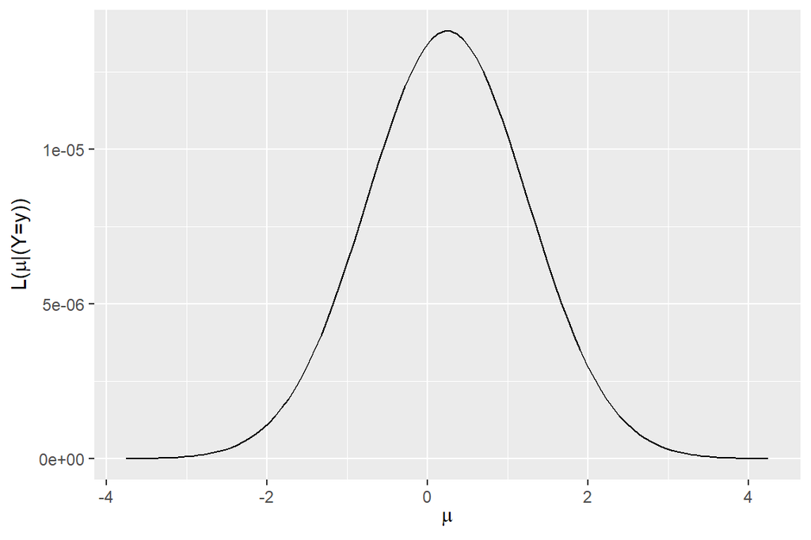

```r
# Vierohodnostná funkcia
plot_normal_likelihood(y = y, sigma = sd) # odchylku neodhadujeme, je urcena vopred
```

#### Vierohodnostná funkcia podľa vzorca pre naše dáta:

Pre naše dáta:

```
## Známa odchýlka sigma: 2
## Priemer pozorovaných hodnôt: 0.25, počet pozorovaných hodnôt: 4
```

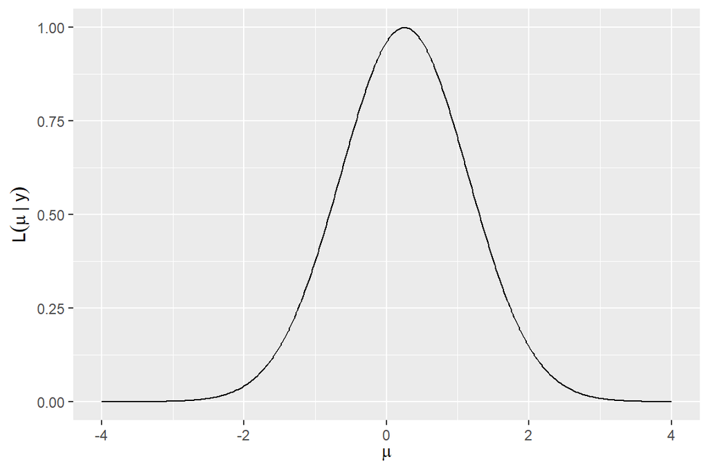

```r
# Vierohodnostná funkcia podla vzorca
xl <- seq(from = -4, to = 4, length = 501)
yl <- exp(-(0.25-xl)^2/1.6)
df <- data.frame(xl, yl)
ggplot(data = df, mapping = aes(x = xl, y = yl)) +
  geom_line() +
  labs(x = expression(mu), y = expression(L(mu~"|"~y)))
```

### b. Vykresliť priorné pdf, vierohodnostnú funkciu a posteriorné pdf pre $\mu$

**Posteriorný model** Posteriorny model je proporcionálny súčinu apriorneho modelu a vierohodnostného modelu:

> Na začiatku apriórny model, ktorý má normálne rozdelenie:
> $$\begin{split}
> \mu \sim N(\theta, \tau^2) \\
> \end{split}$$

> Jednotlivé pozorovania majú normálne rozdelenie:
> $$\begin{split}
> Y_i | \mu \; \sim \; N(\mu, \sigma^2) \\
> \end{split}$$

> Na základe apriórneho modelu a pozorovania dát –> posteriórny Normal model:
> $$\begin{equation}
> \mu|\vec{y} \; \sim \; N\bigg(\theta\frac{\sigma^2}{n\tau^2+\sigma^2} +
> \bar{y}\frac{n\tau^2}{n\tau^2+\sigma^2}, \;
> \frac{\tau^2\sigma^2}{n\tau^2+\sigma^2}\bigg)
> \end{equation}$$
> kde $\overline{y}$ je priemernou hodnotou poZorovaní $\vec{y} = (y_1,y_2,\ldots,y_n)$

#### Graf pre apriórný, vierohodnostný aj posteriórny model

V grafe vidíme rozdelenia všetkých troch modelov.

[figure not shown]

```r
# Zobrazenie prioru, vierohodnosti a posterioru
  # theta, tau - from prior
  # sd - supposed to be constant
  # y_bar, n - from data
plot_normal_normal(mean = theta, sd = tau, sigma = sd, y_bar = mean(y) , n = length(n))
```

#### Posteriórny model pre naše dáta podľa vzorca

> $$\begin{split}
> \mu|\vec{y} & \sim N\bigg(\theta\frac{\sigma^2}{n\tau^2+\sigma^2} +
> \bar{y}\frac{n\tau^2}{n\tau^2+\sigma^2},
> \frac{\tau^2\sigma^2}{n\tau^2+\sigma^2}\bigg) \\
> \mu|\vec{y} & \sim N\bigg(7.2\cdot\frac{2^2}{4\cdot2.6^2+2^2} +
> {0.25}\frac{4*2.6^2}{4\cdot2.6^2+2^2},
> \frac{2.6^2*2^2}{4*2.6^2+2^2}\bigg) \\
> \mu|\vec{y} & \sim N\bigg(1.1456, 0.9333\bigg)
> \end{split}$$

```
## Vypočítaná stredná hodnota pre posterior podľa vzorca: 1.145619
## smerodajná odchýlka: 0.9333456
```

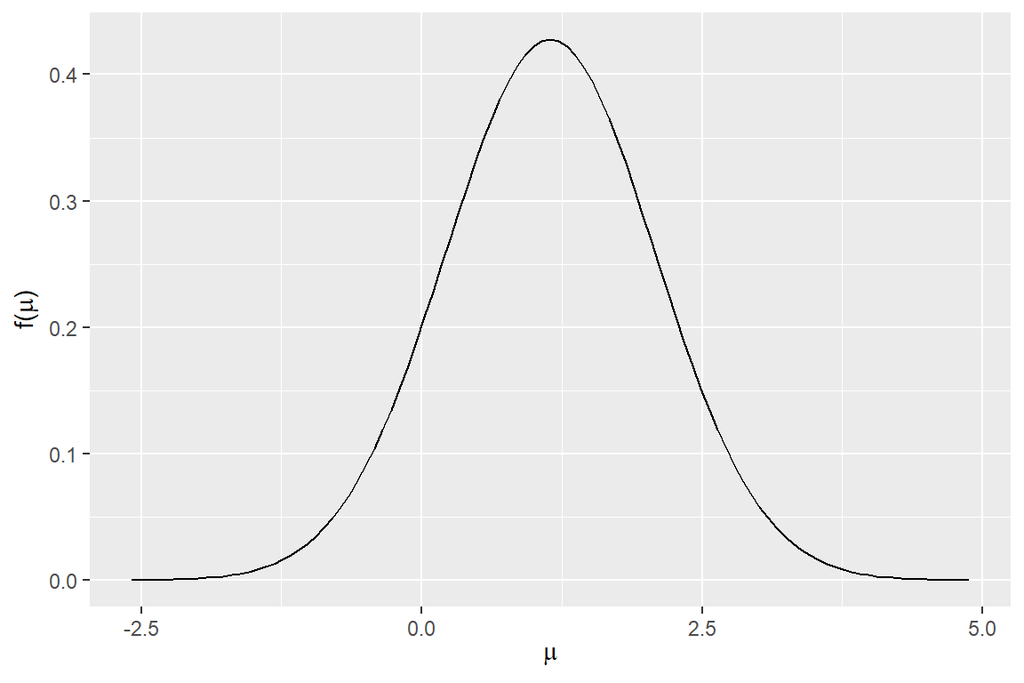

### c. Porovnať charakteristiky apriórneho a posteriórneho modelu

```
##       model     mean     mode      var        sd
## 1     prior 7.200000 7.200000 6.760000 2.6000000
## 2 posterior 1.145619 1.145619 0.871134 0.9333456
```

```
## Váha strednej hodnoty z priórneho modelu je: 0.128866
## váha strednej hodnoty z dát je: 0.871134
```

### d. Zhodnotenie výsledkov

Na začiatku sme predpokladali, že priemerná zmena akcie je 7,2+-2,6. Avšak pozorované dáta majú priemer len 0,25. Preto sa stredná hodnota aposteriórnej hustoty výrazne posunula doľava do 1,146. Posteriórny model je váženým priemerom priórnej hustoty a dát. Váha apriórnej strednej hodnoty je oveľa nižšia ako z dát, preto je posteriórna stredná hodnota bližšia k dátovej.

### e. Pravdepodobnosť poklesu pre posteriórny model

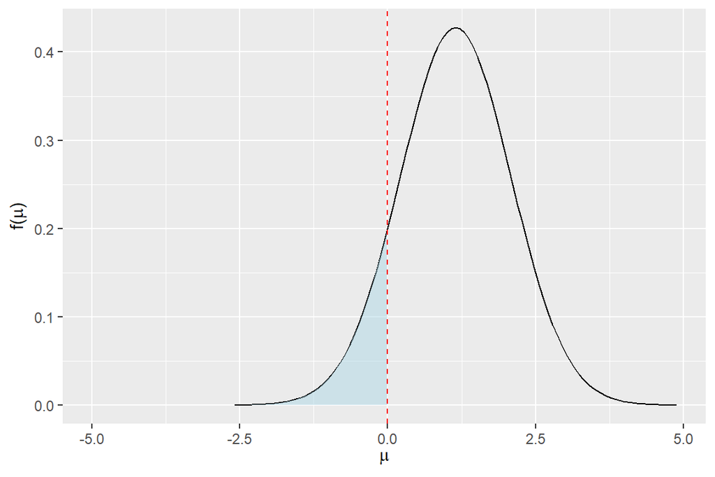

```
## Pravdepodobnosť poklesu:
## Pôvodne:  0.0028
## Teraz 0.1098
```

### f. Pravdepodobnosť rastu o viac ako 8 pre posteriórny model

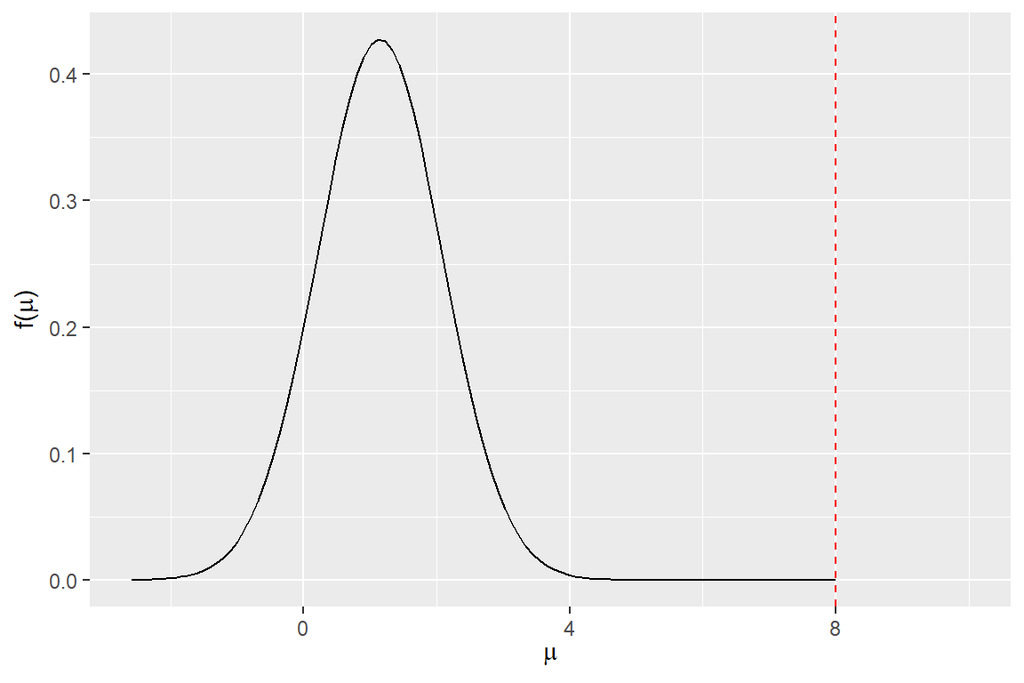

```
## Pravdepodobnosť rastu o viac ako 8:
## Pôvodne:  0.3792
## Teraz 1.037418e-13
```

# Exercise 5.19: The Beta-Geometric Model

*Zdroj: [Exercise 5.19](https://www.bayesrulesbook.com/chapter-5#exercises-4)*

Odvodenie Beta-Geometrického modelu a dokázanie konjugovanosti Beta prioru pre Geometrický dátový model.

> Zvážte nasledujúci nový Bayesovský model:
> $$\begin{split}
> Y|\theta & \sim \text{Geometric}(\theta) \\
> \theta & \sim \text{Beta}(\alpha, \beta) \\
> \end{split}$$

> kde Geometrický model má pravdepodobnostnú funkciu (pmf) $f(y|\theta) = \theta (1 - \theta)^{y - 1}$ pre $y \in \{1,2,\ldots\}$.
> 1. Odvoďte posteriórny model pre $\theta$ pri zadaných pozorovaných dátach $Y = y$. Ak je to možné, identifikujte názov posteriórneho modelu a jeho parametre.
> 2. Je Beta model konjugovaným priorom pre Geometrický dátový model?

## Solution

### a. Odvodenie posteriórneho modelu pre $\theta$

#### Krok 1: Definícia apriórneho modelu (Beta rozdelenie)

> Apriórny model pre parameter $\theta$ je Beta rozdelenie:
> $$\begin{equation}
> \theta \sim \text{Beta}(\alpha, \beta)
> \end{equation}$$

> Hustota pravdepodobnosti (pdf) Beta rozdelenia je:
> $$\begin{equation}
> f(\theta) = \frac{\Gamma(\alpha + \beta)}{\Gamma(\alpha)\Gamma(\beta)}
> \theta^{\alpha-1}(1-\theta)^{\beta-1} \;\; \text{pre } \theta \in [0,1]
> \end{equation}$$
> Pri ďalšom odvodzovaní aposteriórnej hustoty stačí používať iba **jadro** Beta rozdelenia, t.j. môžeme vypustiť časti funkcie, ktoré nezávisia od parametra $theta$:
> $$\begin{equation}
> f(\theta) \propto \theta^{\alpha-1}(1-\theta)^{\beta-1}
> \end{equation}$$

#### Krok 2: Vierohodnostný model (Geometrické rozdelenie)

Geometrické rozdelenie modeluje počet pokusov potrebných na dosiahnutie prvého úspechu, kde $\theta$ je pravdepodobnosť úspechu v jednom pokuse.

> Funkcia hustoty Geometrického rozdelenia s pravdepodobnosťou $theta$ je:
> $$\begin{equation}
> f(y|\theta) = \theta (1 - \theta)^{y - 1} \;\; \text{pre } y \in
> \{1,2,\ldots\}
> \end{equation}$$

> Po pozorovaní dát $Y = y$ máme vierohodnostnú funkciu (likelihood). Tvar funkcie je rovnaký ako pre funkciu hustoty, mení sa len chápanie paramerov (tu je parametrom $theta$).
> $$\begin{equation}
> L(\theta|y) = \theta(1-\theta)^{y-1} \;\; \text{pre } \theta \in [0,1]
> \end{equation}$$

#### Krok 3: Výpočet jadra posteriórneho modelu

Podľa Bayesovej vety je posteriórna hustota pravdepodobnosti pre $\theta$ proporcionálna k súčinu apriórnej hustoty a vierohodnostnej funkcie:

> $$\begin{equation}
> f(\theta|y) \propto f(\theta) \cdot L(\theta|y)
> \end{equation}$$

> Ako apriórnu hustotu dosadíme len jadro (stačí to) a vierohodnosť, potom poupravujeme:
> $$\begin{split}
> f(\theta|y) & \propto \theta^{\alpha-1}(1-\theta)^{\beta-1} \cdot
> \theta(1-\theta)^{y-1} = \\
> & = \theta^{\alpha-1} \cdot \theta^1 \cdot (1-\theta)^{\beta-1}
> \cdot \theta(1-\theta)^{y-1} = \\
> & = \theta^{\alpha-1+1} \cdot (1-\theta)^{\beta-1+y-1} = \\
> & = \theta^{\alpha} \cdot (1-\theta)^{\beta+y-2} \\
> \end{split}$$

#### Krok 4: Odvodenie rozdelenia pre posteriórny model

> Čiže apriórna hustota pre **$Beta(\alpha, \beta)$** mala jadro:
> $$\begin{equation}
> f(\theta) \propto \theta^{\alpha-1}(1-\theta)^{\beta-1}
> \end{equation}$$

> Posteriórna hustota má jadro:
> $$\begin{equation}
> f(\theta) \propto \theta^{\alpha} \cdot (1-\theta)^{\beta+y-2}
> \end{equation}$$
> Preto parametre pre posteriórnu hustotu sú (+1 k obom exponentom):
> - $\alpha_post$ = $\alpha$ + 1
> - $\beta_post$ = $\beta + y - 2 + 1$ = $\beta + y - 1$

> To zodpovedá **Beta rozdeleniu** s parametrami $(\alpha+1, \beta+y-1)$.

**Posteriórny model pre $\theta$ je teda:**

> $$\begin{equation}
> \boxed{\theta|y \sim \text{Beta}(\alpha + 1, \; \beta + y - 1)}
> \end{equation}$$

### b. Je Beta model konjugovaný prior?

Beta model **je konjugovaný apriórny model** pre Geometrický dátový model. Lebo posteriórny model patrí do tej istej rodiny rozdelení, je to tiež Beta model (s inými parametrami).

**Aktualizácia parametrov $\alpha a \beta$:**

> Po dátach $Y = y$ (počet pokusov do prvého úspechu) sa parametre aktualizujú:
> - Parameter $\alpha$ sa aktualizuje na: $\alpha \rightarrow \alpha + 1$
> - Parameter $\beta$ sa aktualizuje: $\beta \rightarrow \beta + y - 1$
> - Prior: $\text{Beta}(\alpha, \beta) \rightarrow \text{Beta}(\alpha + 1, \beta + y - 1)$

**Interpretácia parametrov:**

- $\alpha$ reprezentuje počet predchádzajúcich úspechov
- $\beta$ reprezentuje počet predchádzajúcich neúspechov
- Po pozorovaní $y$ pokusov s jedným úspechom na konci  
  - pridáme 1 úspech ($\alpha + 1$)  
  - pridáme $y-1$ neúspechov pred úspechom ($\beta + y - 1$)